# Homework 4

Mel Zarate

10/23/2019

[1] Write a simple R function, Z.prop.test(), that can perform one- or two-sample Z-tests for proportion data, using the following guidelines:

Your function should take the following arguments: p1 and n1 (no default) representing the estimated proportion and sample size (i.e., based on your sample data); p2 and n2 (both defaulting to NULL) that contain a second sample’s proportion and sample size data in the event of a two-sample test; p0 (no default) as the expected value for the population proportion; and alternative (default “two.sided”) and conf.level (default 0.95), to be used in the same way as in the function t.test().

The function should contain a check for the rules of thumb we have talked about (n∗p>5 and n∗(1−p)>5) to ensure the validity of assuming the normal distribution in both the one- and two-sample settings. If this is violated, the function should still complete but it should also print an appropriate warning message.

```r
#first the one sample- normality guidelines:
z.test <- function(p1,n1,p0,p2=NULL,n2=NULL,conf.level=0.95,alternative="two.sided") {
   if(p1 == 0){
    return(0)}
    else {if((n1 * p1 < 5) | (n1 * (1-p1) > 5)){
          return(c("Warning: Not Normal", (p1-p0) / sqrt((p0 * (1-p0))/n1)))}
          else(return((p1-p0) / sqrt((p0 * (1-p0))/n1)))}
}
#now a function for two sample test
z.test.2 <- function(p1,n1,p0,p2,n2,conf.level=0.95,alternative="two.sided") {
   if(p1 == 0){
    return(0)}
    else {if((n1 * p1 < 5) | (n1 * (1-p1) > 5)){
          return(c("Warning: Not Normal", (p1-p0) / sqrt((p0 * (1-p0))/n1)))}
          else(return((p1-p0) / sqrt((p0 * (1-p0))/n1)))}
  #for second sample
  if(p2 == 0){
    return(0)}
    else {if((n2 * p2 < 5) | (n2 * (1-p2) > 5)){
          return(c("Warning: Not Normal", (p2-p0) / sqrt((p0 * (1-p0))/n2)))}
          else(return((p2-p0) / sqrt((p0 * (1-p0))/n2)))}
}
```

When conducting a two-sample test, it should be p1 that is tested as being smaller or larger than p2 when alternative=“less” or alternative=“greater”, the same as in the use of x and y in the function t.test(). trying this with hypothetical values:

```r
#one sample: sample proportion is 10%, size is 100, expected populaiton proportion is 25%
z.test(p1=.10,n1=100,p0=.25,p2=NULL,n2=NULL,conf.level=0.95,alternative="two.sided")
```

```
## [1] "Warning: Not Normal" "-3.46410161513775"
```

```r
#yay it worked! not normal but at least it told me.
#two sample test:
z.test.2(p1=.10,n1=100,p0=.25,p2=.15,n2=50,conf.level=0.95,alternative="two.sided")
```

```
## [1] "Warning: Not Normal" "-3.46410161513775"
```

I’m not sure why I’m getting the same value here, or what that value is even supposed to represent.

The function should return a list containing the members Z (the test statistic), P (the appropriate p value), and CI (the two-sided CI with respect to “conf.level” around p1 in the case of a one-sample test and around p2-p1 in the case of a two-sample test). For all test alternatives (“two.sided”, “greater”, “less”), calculate symmetric CIs based on quantiles of the normal distribution rather than worrying about calculating single-limit confidence bounds. #Howwww do I get all of this?!?

[2] The dataset from Kamilar and Cooper has in it a large number of variables related to life history and body size. Fit the regression model and, using {ggplot2}, produce a scatterplot with the fitted line superimposed upon the data. Append the the fitted model equation to your plot (HINT: use the function geom_text()).

Download the data

```r
library(curl)
f <- curl("https://raw.githubusercontent.com/fuzzyatelin/fuzzyatelin.github.io/master/AN597_Fall19/KamilarAndCooperData.csv")
d <- read.csv(f, header = TRUE, sep = ",", stringsAsFactors = FALSE)
head(d)
```

```
##               Scientific_Name          Family          Genus      Species
## 1 Allenopithecus_nigroviridis Cercopithecidae Allenopithecus nigroviridis
## 2         Allocebus_trichotis Cercopithecidae      Allocebus    trichotis
## 3           Alouatta_belzebul        Atelidae       Alouatta     belzebul
## 4             Alouatta_caraya        Atelidae       Alouatta       caraya
## 5            Alouatta_guariba        Atelidae       Alouatta      guariba
## 6           Alouatta_palliata        Atelidae       Alouatta     palliata
##   Brain_Size_Species_Mean Brain_Size_Female_Mean   Brain_size_Ref
## 1                   58.02                  53.70 Isler et al 2008
## 2                      NA                     NA
## 3                   52.84                  51.19 Isler et al 2008
## 4                   52.63                  47.80 Isler et al 2008
## 5                   51.70                  49.08 Isler et al 2008
## 6                   49.88                  48.04 Isler et al 2008
##   Body_mass_male_mean Body_mass_female_mean Mass_Dimorphism
```

[output cut: 69 more lines]

For this exercise, the end aim is to fit a simple linear regression model to predict longevity (MaxLongevity_m) measured in months from species’ brain size (Brain_Size_Species_Mean) measured in grams. Do the following for both longevity~brain size and log(longevity)~log(brain size):

First lets plot the two variables.

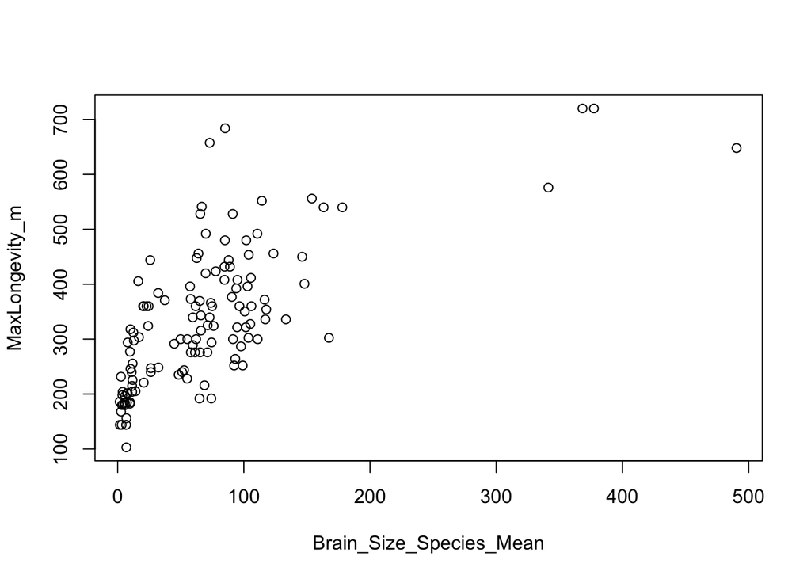

```r
plot(data = d, MaxLongevity_m ~ Brain_Size_Species_Mean)
```

make the model:

```r
model <- lm(data = d, MaxLongevity_m ~ Brain_Size_Species_Mean)
summary(model)
```

```
##
## Call:
## lm(formula = MaxLongevity_m ~ Brain_Size_Species_Mean, data = d)
##
## Residuals:
##     Min      1Q  Median      3Q     Max
## -198.27  -61.92  -17.78   56.16  331.36
##
## Coefficients:
##                         Estimate Std. Error t value Pr(>|t|)
## (Intercept)             248.9523    11.1111   22.41   <2e-16 ***
## Brain_Size_Species_Mean   1.2180     0.1101   11.06   <2e-16 ***
## ---
## Signif. codes:  0 '***' 0.001 '**' 0.01 '*' 0.05 '.' 0.1 ' ' 1
##
## Residual standard error: 90.91 on 126 degrees of freedom
##   (85 observations deleted due to missingness)
## Multiple R-squared:  0.4928, Adjusted R-squared:  0.4887
## F-statistic: 122.4 on 1 and 126 DF,  p-value: < 2.2e-16
```

R squared: 0.4928 not too great but shows *some* correlation.

Let’s look if we are fitting assumptions of a linear model

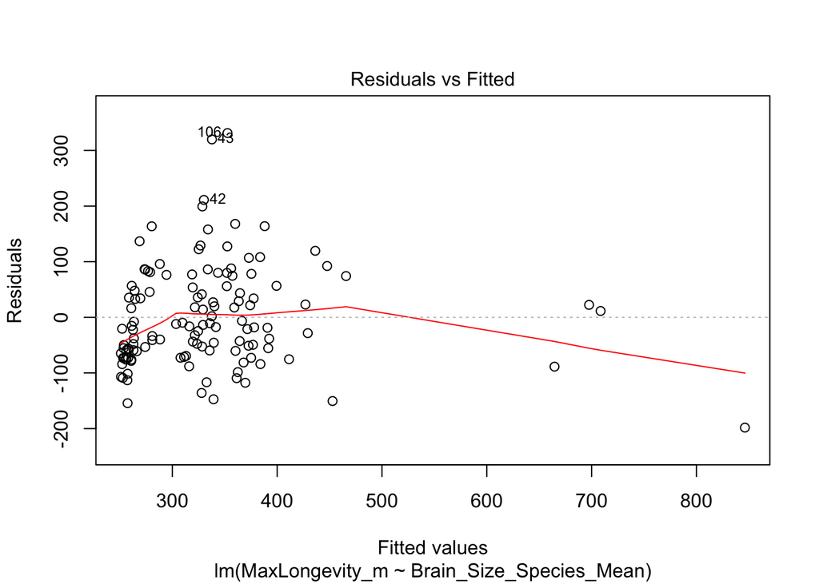

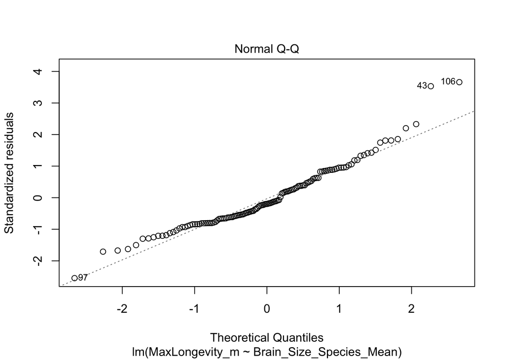

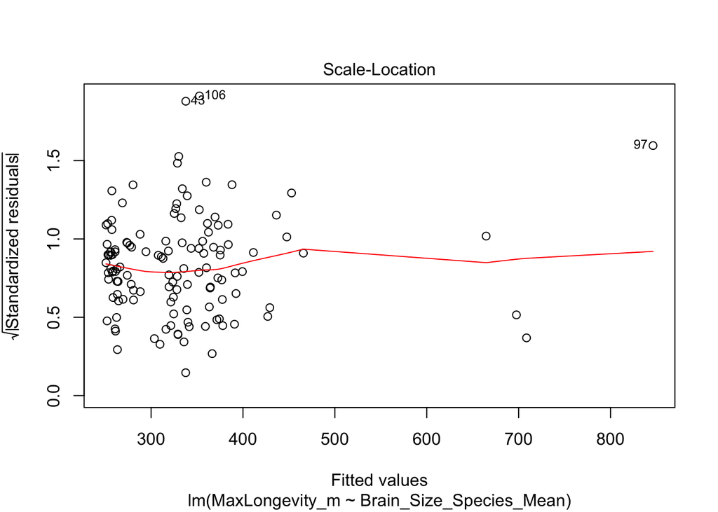

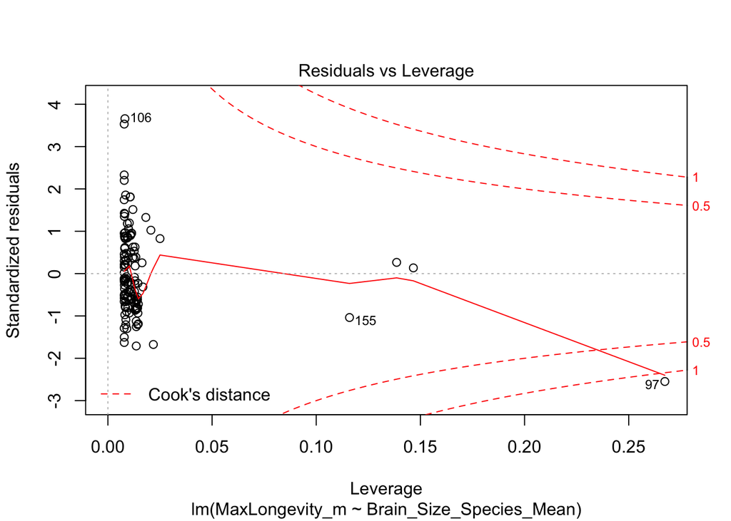

```r
plot(model)
```

…. that kind of looks like garbage.

So it definitely is not linear.

## Data Transformation

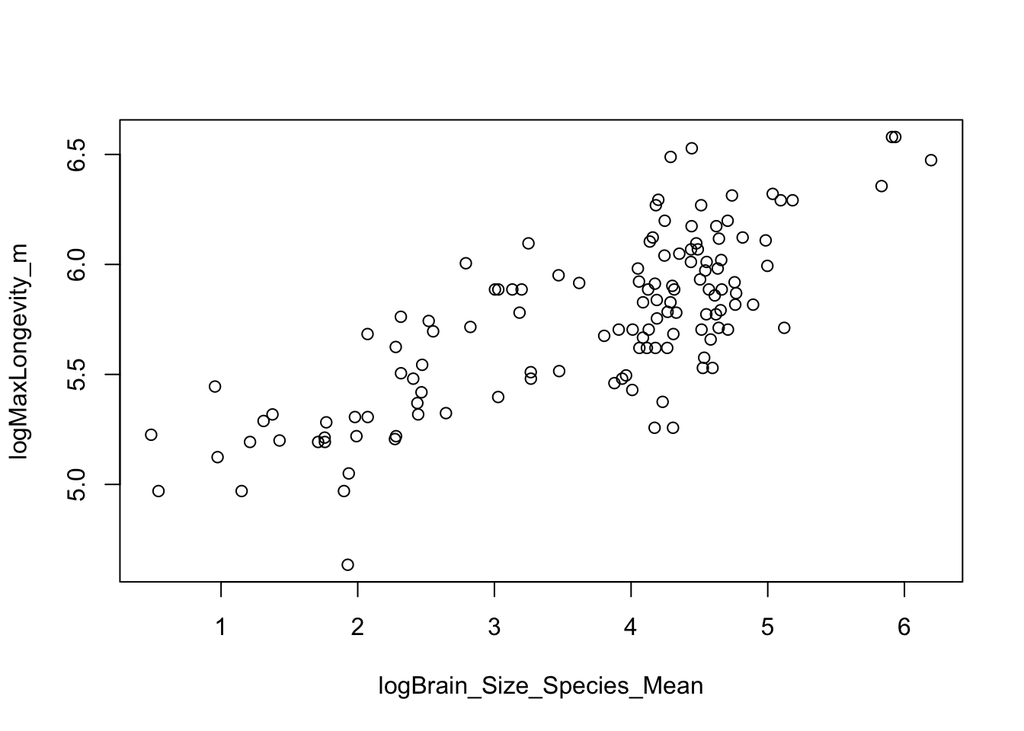

```r
d$logMaxLongevity_m <- log(d$MaxLongevity_m)
d$logBrain_Size_Species_Mean <- log(d$Brain_Size_Species_Mean)
plot(data = d, logMaxLongevity_m ~ logBrain_Size_Species_Mean)
```

```r
model <- lm(data = d, logMaxLongevity_m ~ logBrain_Size_Species_Mean)
summary(model)
```

```
##
## Call:
## lm(formula = logMaxLongevity_m ~ logBrain_Size_Species_Mean,
##     data = d)
##
## Residuals:
##     Min      1Q  Median      3Q     Max
## -0.6955 -0.1750 -0.0097  0.1788  0.6084
##
## Coefficients:
##                            Estimate Std. Error t value Pr(>|t|)
## (Intercept)                 4.87895    0.06907   70.63   <2e-16 ***
## logBrain_Size_Species_Mean  0.23415    0.01781   13.15   <2e-16 ***
## ---
## Signif. codes:  0 '***' 0.001 '**' 0.01 '*' 0.05 '.' 0.1 ' ' 1
##
## Residual standard error: 0.2485 on 126 degrees of freedom
##   (85 observations deleted due to missingness)
## Multiple R-squared:  0.5784, Adjusted R-squared:  0.5751
## F-statistic: 172.9 on 1 and 126 DF,  p-value: < 2.2e-16
```

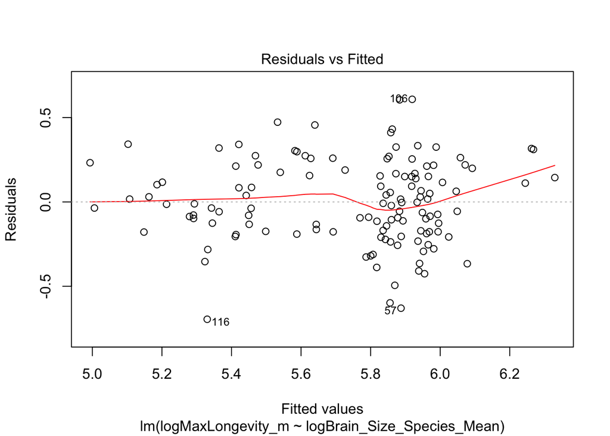

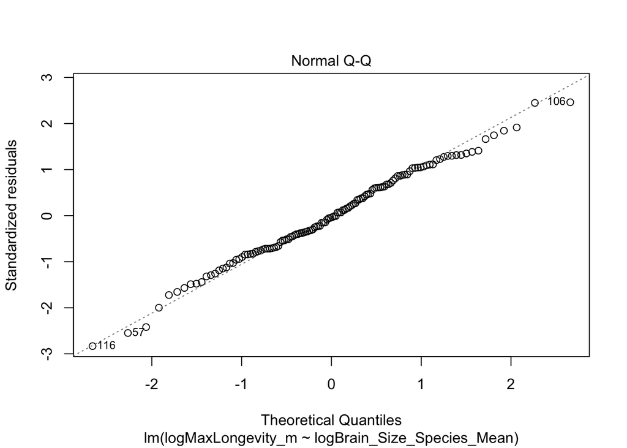

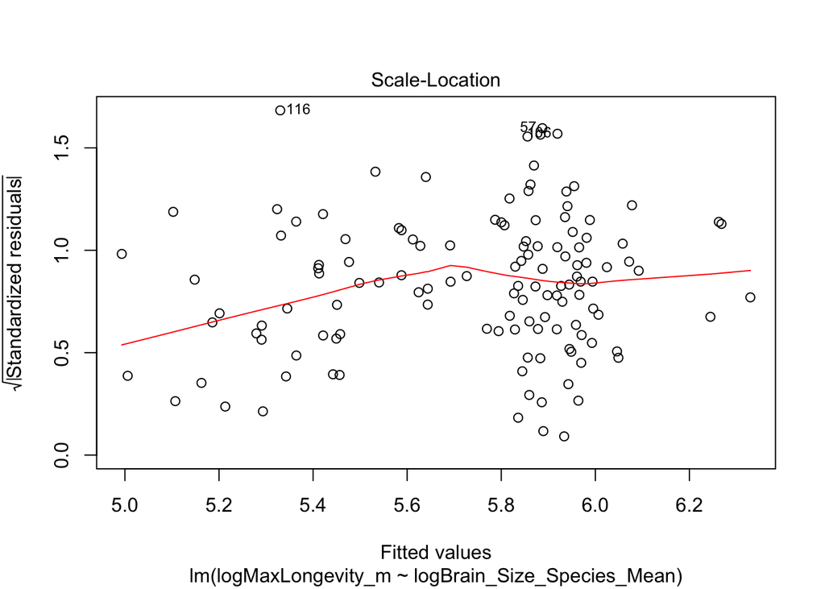

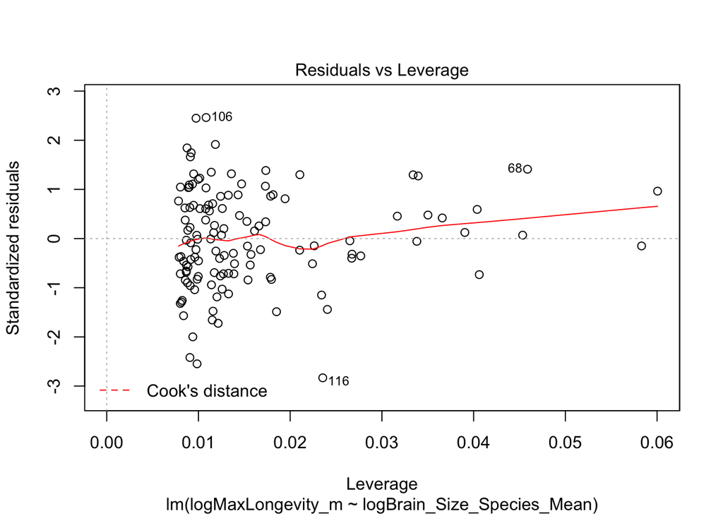

```r
plot(model)
```

R squared is a little better, and the plot is definitely a bit better.

the car plot (for the pretty Q-Q):

```r
library(car)
```

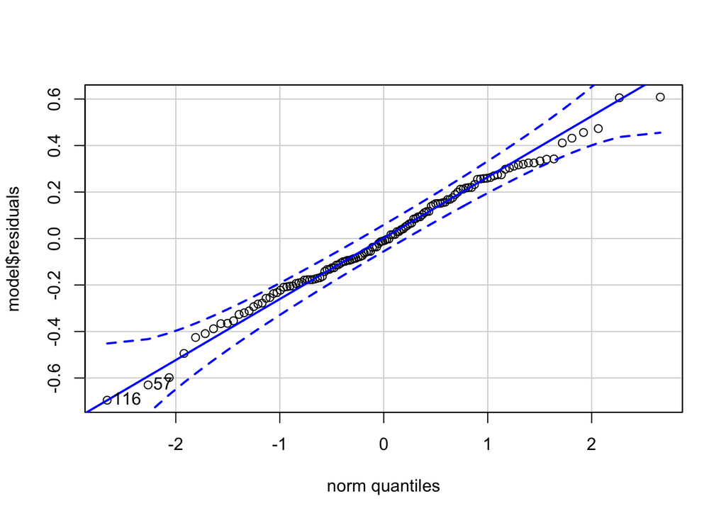

```
## 116  57
##  71  35
```

```r
qqPlot(model$residuals)
```

Everything is in the confidence intervals!

Identify and interpret the point estimate of the slope (β1), as well as the outcome of the test associated with the hypotheses H0: β1 = 0; HA: β1 ≠ 0.

So this is what I want to run a line through and find the slope:

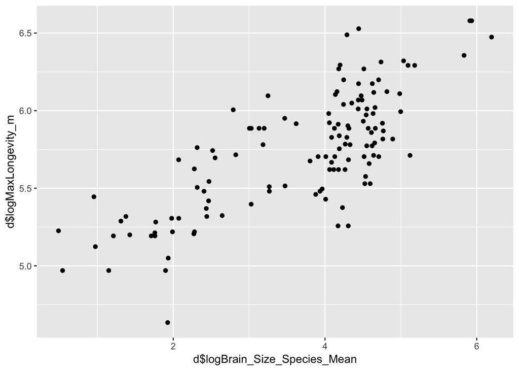

```r
library(ggplot2)
g <- ggplot(data = d, aes(x = d$logBrain_Size_Species_Mean, y = d$logMaxLongevity_m)) + geom_point()
g
```

```r
b <- d$logBrain_Size_Species_Mean
l <- d$logMaxLongevity_m
beta1 <- cor(b,l)/var(b)
beta1
```

```
## [1] NA
```

I don’t know what this is giving me NA, so I’m going to try to look at it with the lm() function.

```r
m <- lm(l ~ b)
m
```

```
##
## Call:
## lm(formula = l ~ b)
##
## Coefficients:
## (Intercept)            b
##      4.8790       0.2341
```

So this means that the slope is 0.23!!! (And I definitely could have just looked at this before)

Also, find a 90 percent CI for the slope (β1) parameter. Using your model, add lines for the 90 percent confidence and prediction interval bands on the plot and add a legend to differentiate between the lines.

To do this part, I am going to use the lmodel2 package #do I do this for the logged variables as well?

```r
library(lmodel2)  # load the lmodel2 package
mII <- lmodel2(MaxLongevity_m ~ Brain_Size_Species_Mean, data = d, range.y = "relative", range.x = "relative",
    nperm = 1000)
mII
```

```
##
## Model II regression
##
## Call: lmodel2(formula = MaxLongevity_m ~ Brain_Size_Species_Mean,
## data = d, range.y = "relative", range.x = "relative", nperm =
## 1000)
##
## n = 128   r = 0.7019753   r-square = 0.4927693
## Parametric P-values:   2-tailed = 2.685909e-20    1-tailed = 1.342954e-20
## Angle between the two OLS regression lines = 17.35978 degrees
##
## Permutation tests of OLS, MA, RMA slopes: 1-tailed, tail corresponding to sign
## A permutation test of r is equivalent to a permutation test of the OLS slope
## P-perm for SMA = NA because the SMA slope cannot be tested
##
## Regression results
##   Method Intercept    Slope Angle (degrees) P-perm (1-tailed)
## 1    OLS  248.9523 1.217990        50.61316       0.000999001
## 2     MA  185.9393 2.121962        64.76728       0.000999001
## 3    SMA  212.9069 1.735090        60.04348                NA
## 4    RMA  204.1621 1.860542        61.74296       0.000999001
##
## Confidence intervals
##   Method 2.5%-Intercept 97.5%-Intercept 2.5%-Slope 97.5%-Slope
## 1    OLS       226.9637        270.9408   1.000130    1.435851
## 2     MA       154.8589        209.0668   1.790180    2.567837
## 3    SMA       196.7709        227.1436   1.530853    1.966575
## 4    RMA       177.9787        225.1284   1.559764    2.236164
##
## Eigenvalues: 19247.81 2287.528
##
## H statistic used for computing C.I. of MA: 0.004757621
```

```r
mII <- lmodel2(logMaxLongevity_m ~ logBrain_Size_Species_Mean, data = d, range.y = "relative", range.x = "relative",
    nperm = 1000)
mII
```

```
##
## Model II regression
##
## Call: lmodel2(formula = logMaxLongevity_m ~
## logBrain_Size_Species_Mean, data = d, range.y = "relative",
## range.x = "relative", nperm = 1000)
##
## n = 128   r = 0.7605319   r-square = 0.5784088
## Parametric P-values:   2-tailed = 2.165214e-25    1-tailed = 1.082607e-25
## Angle between the two OLS regression lines = 8.86056 degrees
##
## Permutation tests of OLS, MA, RMA slopes: 1-tailed, tail corresponding to sign
## A permutation test of r is equivalent to a permutation test of the OLS slope
## P-perm for SMA = NA because the SMA slope cannot be tested
##
## Regression results
##   Method Intercept     Slope Angle (degrees) P-perm (1-tailed)
## 1    OLS  4.878951 0.2341496        13.17837       0.000999001
## 2     MA  4.845118 0.2433500        13.67708       0.000999001
## 3    SMA  4.607832 0.3078761        17.11235                NA
## 4    RMA  4.848889 0.2423246        13.62160       0.000999001
##
## Confidence intervals
##   Method 2.5%-Intercept 97.5%-Intercept 2.5%-Slope 97.5%-Slope
## 1    OLS       4.742256        5.015646  0.1989063   0.2693928
## 2     MA       4.709198        4.978767  0.2070061   0.2803112
## 3    SMA       4.470836        4.730040  0.2746434   0.3451299
## 4    RMA       4.713682        4.982094  0.2061014   0.2790917
##
## Eigenvalues: 1.619902 0.05794264
##
## H statistic used for computing C.I. of MA: 0.001195792
```

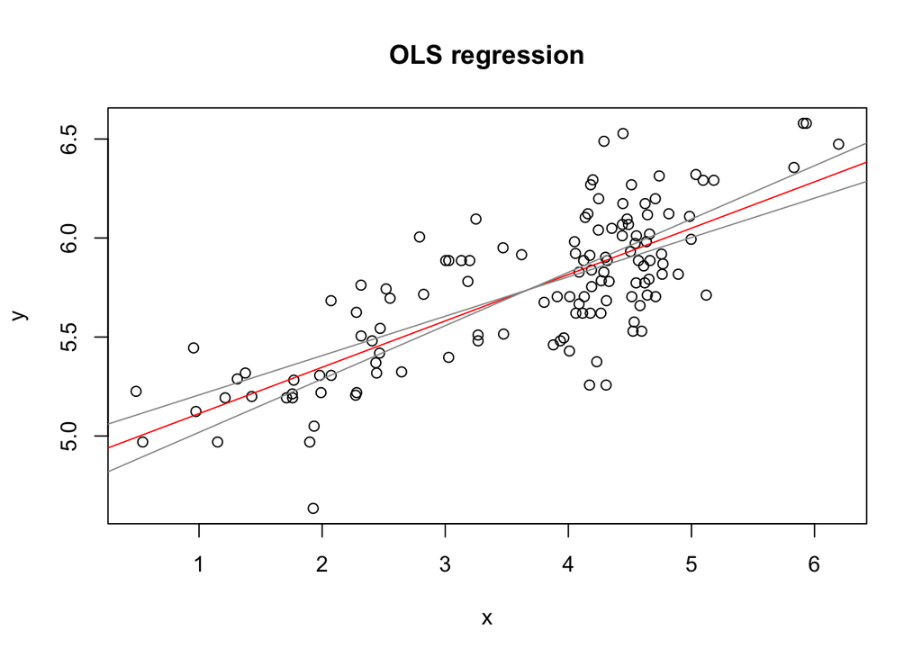

```r
plot(mII, "OLS") #plotting results of tests ran by lmodel2
```

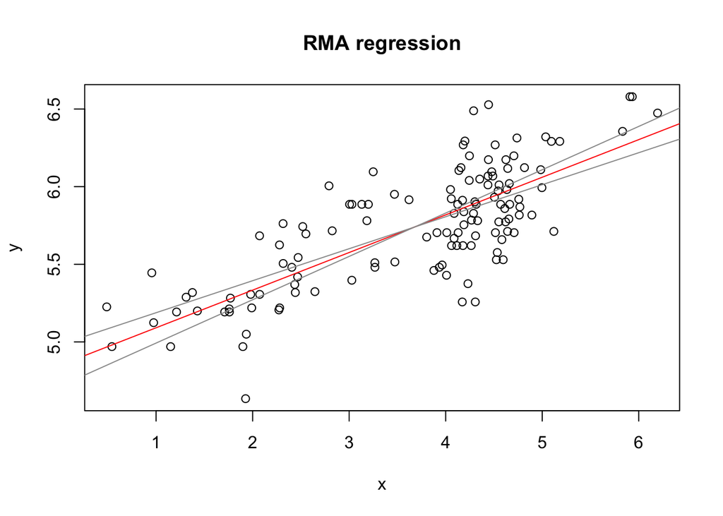

```r
plot(mII, "RMA")
```

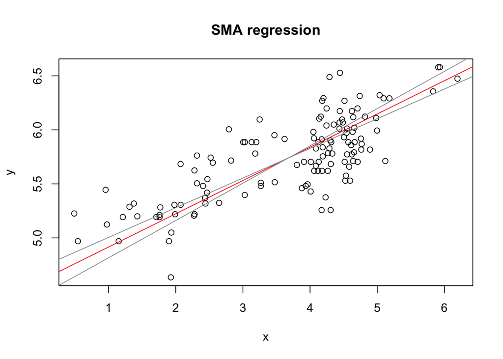

```r
plot(mII, "SMA")
```

They all look about the same.